# HW3_Vikas Sanil

Vikas Sanil

Due Date 2/28

## Packages

```r
# add packages you need for this assignment
library(tidyverse)
library(tigerstats)
library(hexbin)
```

## How to work with this document

There are several ways to format your answer, but whatever you do, please make sure it is *readable* by a human and clean. That is, don’t leave stray comments and commented instructions in your submitted work. You may use a quote code `>` to start your answer after any r/python code chunks you are typing. An example is provided in the first question below.

# Part ONE: Review the approach to location and scale problems for one and two populations (10 points, 5 points each question)

- To find a confidence interval on population mean *when population variance is known*, which of the following should we use? (In this part, suppose X_1, … , X_1000 is a random sample (of size 1000) from some unknown distribution.)

  A. The normal distribution (with the Z statistic)

  B. The normal distribution (with the Z statistic), but ONLY if X comes from a normal distribution

  C. The t-distribution (with the T statistic)

  D. The t-distribution (with the T statistic), but ONLY if X comes from a normal distribution

> Answer: A. The normal distribution (with the Z statistic)
- To find a confidence interval on population mean *when population variance is unknown*, which of the following should we use? (In this part, suppose X_1, … , X_1000 is a random sample (of size 1000) from some unknown distribution.)

  A. The normal distribution (with the Z statistic)

  B. The normal distribution (with the Z statistic), but ONLY if X comes from a normal distribution

  C. The t-distribution (with the T statistic)

  D. The t-distribution (with the T statistic), but ONLY if X comes from a normal distribution

> Answer: The t-distribution (with the T statistic), but ONLY if X comes from a normal distribution

# Part Two: Confidence Interval (20 points)

**Problem 1.** An electrical firm manufactures light bulbs that have a length of life that is approximately normally distributed, with mean equal to 800 hours and a standard deviation of 40 hours. A random sample of 16 bulbs will have an average life of less than 775 hours. (10 points)

1. Give a probabilistic result that indicates how rare an event $\bar{X} \leq 775$ is when $\mu= 800$. On the other hand, how rare would it be if $\mu$ truly were, say, 760 hours?
2. Please construct a 95% confidence interval on $\mu$ with $\bar{X} = 775$. Is 800 inside the interval?

**Pro-tip**: You may use either R or Python or hand-calculations to answer the computational part of this question, however, you do need to–in any case–explain and justify your answer.

**Problem 2.** A maker of a certain brand of low-fat cereal bars claims that the average saturated fat content is 0.5 gram. In a random sample of 8 cereal bars of this brand, the saturated fat content was 0.6, 0.7, 0.7, 0.3, 0.4, 0.5, 0.4, and 0.2. *Assume a normal distribution*. (10 points)

1. Please construct a 95% confidence interval on the average saturated fat content.
2. Would you agree with the claim? Justify your answer.

**Pro-tip**: You may use either R or Python or hand-calculations to answer the computational part of this question, however, you do need to–in any case–explain and justify your answer.

# Part Three: Working With Data (65 points)

### Instructions: Please review EDA Handout first. Import the needed packages first.

- [Obtaining the adult dataset](http://archive.ics.uci.edu/ml/machine-learning-databases/adult/)

### Tasks

For the following exercises, work with the `adult.data` data set. Use either `Python` or `R` to solve each problem. Please read the `adult.name` file to understand each attribute.

1. Import the `adult.data` data set and name it `adult`. (10 points)

```r
url <- "http://archive.ics.uci.edu/ml/machine-learning-databases/adult/adult.data"
adult <- read.csv(url, strip.white = TRUE, header = FALSE)
renameCol<-c("age", "Workclass", "fnlwgt", "education", "educationnum", "maritalstatus", "occupation", "relationship", "race", "sex", "capitalgain", "capitalloss", "hoursperweek", "nativecountry", "salary")
colnames(adult)<-renameCol
```

2. Standardize `hours-per-week` and indicate if there is any outlier (10 points)

```r
hoursPerWeek_z<-scale(adult$hoursperweek)
hoursPerWeek_outliers<-adult[hoursPerWeek_z<-3|hoursPerWeek_z>3,]
numHoursPerweekOutlier<-nrow(hoursPerWeek_outliers)
```

```r
cat("> Answer: The number of outlier when \'hours-per-week\' standardize is ", numHoursPerweekOutlier)
```

[output not shown]

3. Show a bar graph of `race` with a response `class` overlay. What conclusion can you draw from the bar graph? (10 points)

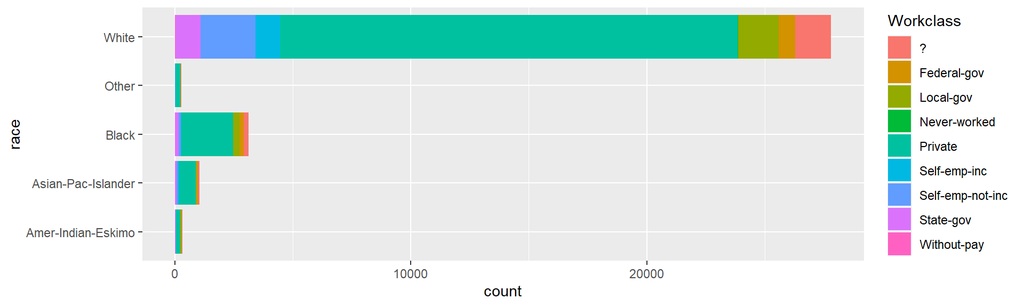

```r
ggplot(data=adult, aes(x = race))+
  geom_bar(aes(fill= Workclass))+
  coord_flip()
```

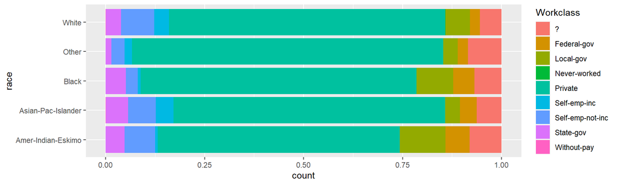

```r
ggplot(data=adult, aes(x = race))+
  geom_bar(aes(fill= Workclass), position = "fill")+
  coord_flip()
```

4. Select any numeric attribute and show a histogram of it with a response `class` overlay. What conclusion can you draw from the histogram? (10 points)

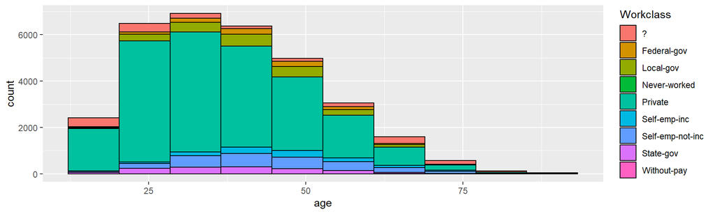

```r
ggplot(data=adult, aes(x = age))+
  geom_histogram(aes(fill= Workclass), bins=10, color ="black")
```

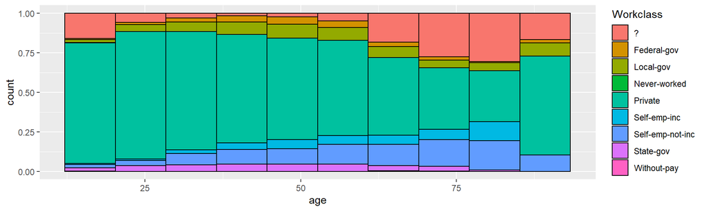

```r
ggplot(data=adult, aes(x = age))+
  geom_histogram(aes(fill= Workclass), bins=10, color ="black", position="fill")
```

5. Select any two attributes and show a plot, what conclusion can you draw from the plot? (10 points)

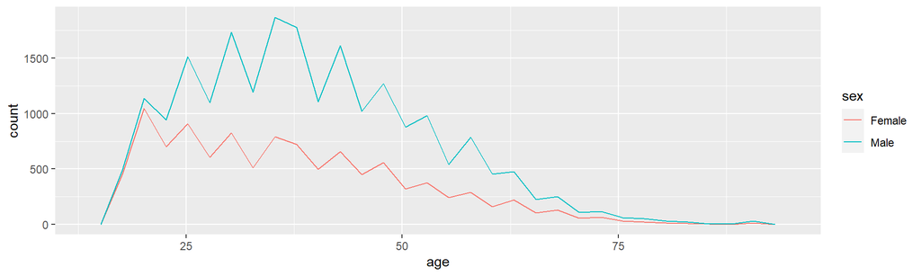

```r
ggplot(data=adult, mapping=aes( x= age))+
  geom_freqpoly(mapping = aes(colour = sex ), bins = 30)
```

6. Select any three attributes and plot their relationship using 2D scatter plot, use one of the selected attributes as the color code when plotting, what can you say about the correlation of these attributes? What conclusion can you draw from the plot? (15 points)

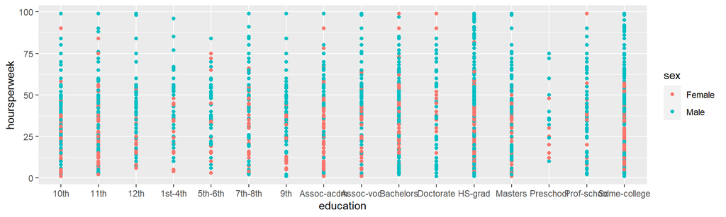

```r
ggplot(data=adult)+
  geom_point(mapping = aes(x= education, y= hoursperweek , colour=sex))
```